# Connect the dots

mleary

June 27, 2020

URL: https://fivethirtyeight.com/features/can-you-connect-the-dots/

# Riddler Express:

In Riddler City, the city streets follow a grid layout, running north-south and east-west. You’re driving north when you decide to play a little game. Every time you reach an intersection, you randomly turn left or right, each with a 50 percent chance.

After driving through 10 intersections, what is the probability that you are still driving north?

## Approach:

Well for the first question, 50% change of driving north. Given an even number of turns, you must be facing South or North in even numbers.

### Setup

Lets generate some helper functions. I figure I need to create random turns based on the available diretions and then repeat the process 10 times.

```r
library(dplyr)

# Generate valid turn options
# Requires a character argument
# returns a character vector
turn_options <- function(direction){

  if(!direction %in% c("North", "East", "South", "West")){
    message("Invalid Direction.  Try 'North', 'South', 'East' or 'West'")
  } else {
  if(direction == "North"){options <- c("West", "North", "East")}
  if(direction == "East"){options <- c("North", "East", "South")}
  if(direction == "South"){options <- c("East", "South", "West")}
  if(direction == "West"){options <- c("South", "West", "North")}
  return(options)
  }

}

# Take a direction and  make a random turn
# Requires a character input
# Returns a character (direction you are heading)
turn_random <- function(direction) {

  turn.options <- turn_options(direction)
  result <- sample(turn.options, 1)
  return(result)

}

# Randomly turn ten times and see where you end up
# Dont love while loop, but hey its quick
turn_10_times <- function(initial.direction = "North"){

  turn.result <- turn_random(initial.direction)
  count <- 1
  while(count < 10){
    turn.result <- turn_random(turn.result)
    count <- count + 1
  }
  return(turn.result)
}
```

Now that we have some helpers, lets generate some simulations. First, we’ll start by simply generating results

```r
trial.count <- 100000

sim <- tibble::tibble(
  trial = 1:trial.count,
  outcome = base::replicate(trial.count, turn_10_times())
)

sim$outcome %>% janitor::tabyl() %>% janitor::adorn_pct_formatting()
```

```
##      .     n percent
##   East 24811   24.8%
##  North 25114   25.1%
##  South 24932   24.9%
##   West 25143   25.1%
```

```r
result <- sim %>%
  summarise(chance.north = sum(ifelse(outcome == "North", 1, 0)) / n())
```

# Plot Paths

For fun, I wanted to go one step further and visualize the path the car could take.

## New Helper Functions

```r
turn_10_times_path <- function(initial.direction = "North"){
  path <- tibble::tibble(
    start  = "start",
    turn1  = turn_random(initial.direction),
    turn2  = turn_random(turn1),
    turn3  = turn_random(turn2),
    turn4  = turn_random(turn3),
    turn5  = turn_random(turn4),
    turn6  = turn_random(turn5),
    turn7  = turn_random(turn6),
    turn8  = turn_random(turn7),
    turn9  = turn_random(turn8),
    turn10 = turn_random(turn9),
  ) %>%
    t() %>%
    # unname() %>%
    as.data.frame() %>%
    tibble::rownames_to_column() %>%
    setNames(c("Turn", "Path"))
  return(path)
}

add_x_coords <- function(dataset, num.turns){
  result.vector <- c(0)
  x <- 0
  for(row in 2:num.turns){
    direction <- dataset$Path[row]
    if(direction == "East"){x <- x + 1}
    if(direction == "West"){x <- x - 1}
    result.vector <- append(result.vector, x)
  }
  dataset <- dataset %>%
    mutate(x = result.vector)
  return(dataset)
}

add_y_coords <- function(dataset, num.turns){
  result.vector <- c(0)
  y <- 0
  for(row in 2:num.turns){
    direction <- dataset$Path[row]
    if(direction == "North"){y <- y + 1}
    if(direction == "South"){y <- y - 1}
    result.vector <- append(result.vector, y)
  }
  dataset <- dataset %>%
    mutate(y = result.vector)
  return(dataset)
}

generate_one_scenario <- function(number.turns = 10, trial.input = 1){
  dat <- turn_10_times_path() %>%
    add_x_coords(num.turns = number.turns+1) %>%
    add_y_coords(num.turns = number.turns+1) %>%
    mutate(trial = trial.input) %>%
    select(trial, everything())
  return(dat)
}

generate_many_trials <- function(trial.count) {
  df.out <- generate_one_scenario()
  trial <- 1
  for(trials in 1:(trial.count-1)){
    trial <- trial + 1
    result.df <- generate_one_scenario(trial.input = trial)
    df.out <- rbind(df.out, result.df)
  }
  return(df.out)
}
```

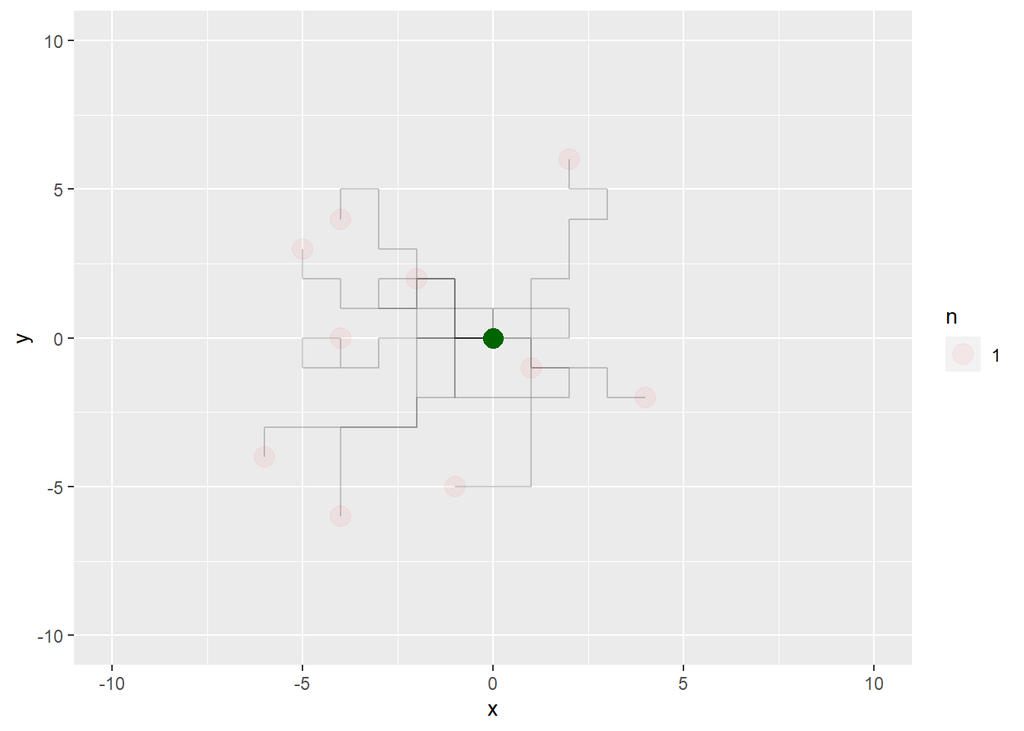

```r
library(ggplot2)

sim <- generate_many_trials(10)

sim %>%
  ggplot(aes(x, y, group = trial)) +
  geom_path(alpha= 0.2) +
  geom_point(aes(x,y, size = n),
             data = sim %>%
               filter(Turn == "turn10") %>%
               add_count(x,y),
             alpha = 0.05,
             color="red") +
  geom_point(aes(x = 0, y =0), color = "darkgreen", size = 4.5) +
  xlim(-10, 10) +
  ylim(-10, 10)
```